# Databases to Documents with RMarkdown

## When **un-**tidy data is okay

Untidy data is often needed for analysis, but it’s not a good way to store data. Instead, join the tables only when needed.

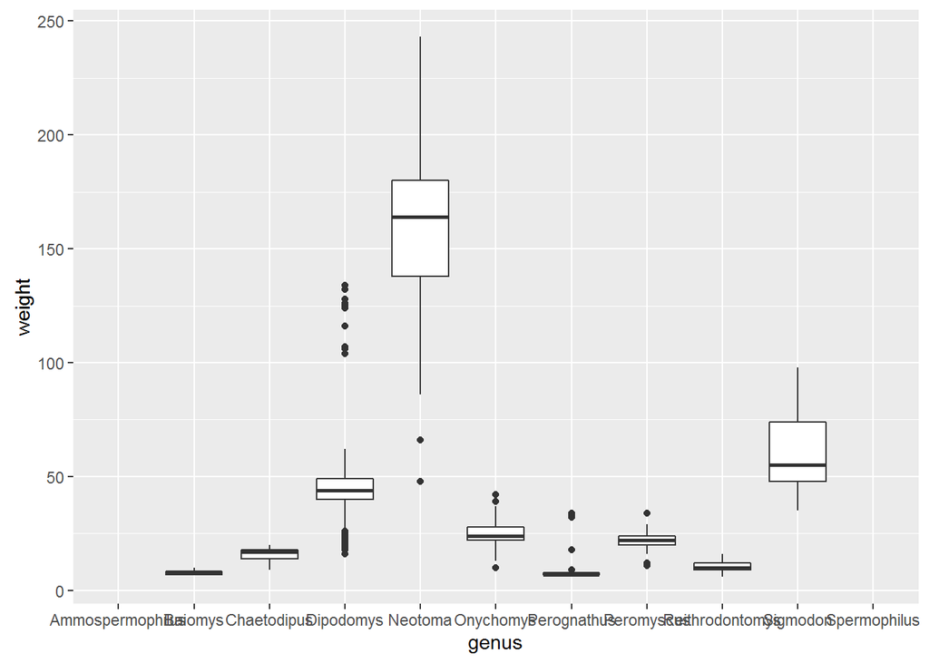

```r
library(ggplot2)
surveys_1990_winter <- filter(surveys, year == 1990) %>%
  select(-year) %>%
  inner_join(species) %>%
  filter(taxa == 'Rodent') %>%
  collect()
ggplot(data = surveys_1990_winter,
       aes(x = genus)) +
  geom_boxplot(aes(y = weight))
```

## Exercise

Create a bar plot for the abundance of species in the rodent taxa.

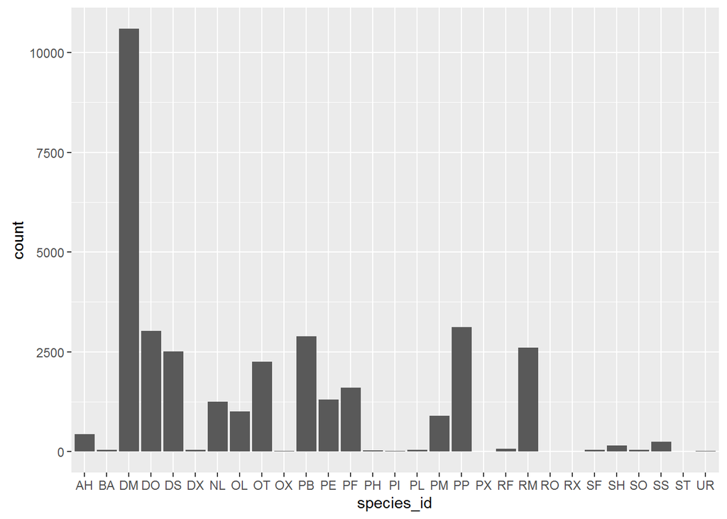

```r
library(ggplot2)
rodents <- surveys %>%
  group_by(species_id) %>%
  summarize(count = n()) %>%
  inner_join(species) %>%
  filter(taxa == 'Rodent') %>%
  collect()
ggplot(data = rodents,
       aes(x = species_id, y = count)) +
  geom_bar(stat = 'identity')
```

## Exercise

The third table, plots, gives details on the plot type. Create a code chunk that shows box plots for the weight of rodents in 1990 across the types of plot.

…